# Communicate Data findings Project - Nawaf alhajri

## Investigation Overview

> In this investigation, we will look at many features related to each trip and its variables we will try to study some feature alone and then try to see the correlations between many of features and give some insights or observations.

## Dataset Overview

> I have chose Ford GoBike Dataset to apply the knowledge on it. We don't have some sharing bikes system like this but in fueture may we need some systems and services like this.

> This dataset describe the data of a public bicycle sharing system called Ford GoBike contains several details about each trip on the bike such as start_station and the duration of the trip.

## (Visualization between age of riders and users types)

> In this iilustration we will know the age of riders , and which user type uses the service more than the another.

**Observations from below plots:**

- Most users are Subscriber with very high percentage as we will see.
- There are many bikers are around age 30.

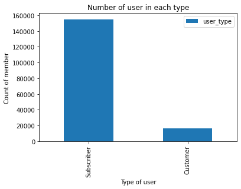

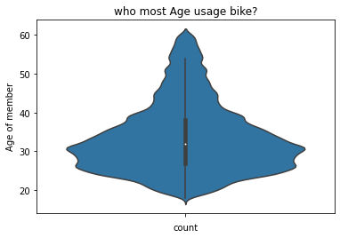

## (Visualization of the duartion range between weekday trips and users types)

> we will show you in this slide the Average Trip Duration on Weekdays , and Weekly usage between User Type .

**Observations from below plots :**

- The riding trips are much shorter on Monday through Friday compared to weekends.
- There was much more subscriber usage than casual customers overall. Especially on weekdays, except for the weekend, there was a decrease

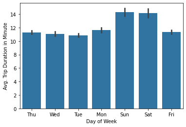

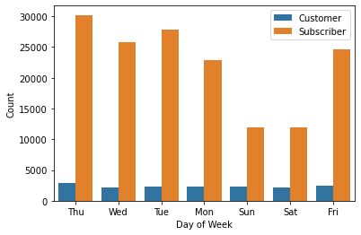

## (Visualization of the duartion weekdays between customers and subscribers and gender)

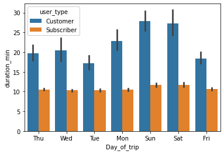

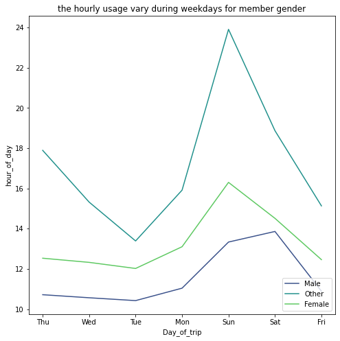